# miRNA DE Analysis

Mike Sovic

3/18/2022

## Overview

Jonathan and Katie have small RNA data for 6 almond samples (3 from each of two age groups). Data are SE50, sequenced by Novogene, and are at /fs/project/PAS0471/osu9453/AgeCohortProject/SmallRNASeq/RawData

## Analysis Workflow

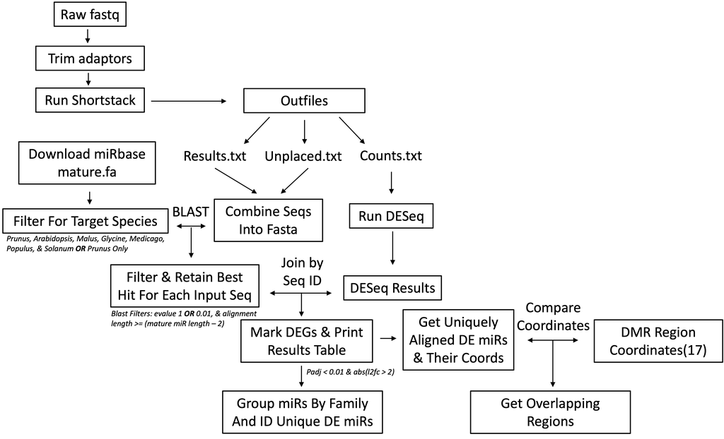

workflow

## Adaptor Trimming: Trimmomatic W/Score 6

Trim adaptors and low quality bases with Trimmomatic - dropped the threshold score to 6 because of the nature of these short reads.

```bash
#script 6_trimmomatic_batch_2.sh

mkdir trim_job_scripts
mkdir trimmed_fastq2

for i in `ls /fs/project/PAS0471/osu9453/AgeCohortProject/SmallRNASeq/RawData`

do

samp=`echo ${i} | sed -E 's/(.fq.gz)//'`
 {
 echo '#PBS -l walltime=02:00:00'
 echo '#PBS -l nodes=1:ppn=3'
 echo '#PBS -A PAS1755'
 echo '#PBS -j oe'

 echo 'cd $PBS_O_WORKDIR'
 echo 'module load trimmomatic'
 echo 'java -jar $TRIMMOMATIC SE -phred33 /fs/project/PAS0471/osu9453/AgeCohortProject/SmallRNASeq/RawData/'${i} 'trimmed_fastq2/'${samp}'.fq.gz ILLUMINACLIP:adaptors/adaptors.fa:2:30:6 LEADING:3 TRAILING:3 SLIDINGWINDOW:6:20 MINLEN:12'

 } > trim_job_scripts/job_trim${base}_2.sh

 qsub trim_job_scripts/job_trim${base}_2.sh

done
```

### Get Read Size Distribution Data

Checking the distribution of read sizes after trimming adaptors. Expect a lot of reads in the ~18-25 bp range.

```bash
#script 7_read_sizes.sh

mkdir read_sizes_6

for i in `ls trimmed_fastq2/*.fq.gz`

do

samp=`echo ${i} | sed -E 's/(.+)(..._.+_.+)(.fq.gz)/\2/'`
 {
 echo '#PBS -l walltime=01:00:00'
 echo '#PBS -l nodes=1:ppn=1'
 echo '#PBS -A PAS1755'
 echo '#PBS -j oe'

 echo 'cd $PBS_O_WORKDIR'
 echo "zcat "${i}" | grep -E '^[ATGCN]{5,}' | awk '{print length}' | sort | uniq -c | sed -E 's/^[[:blank:]]+//' | sed -E 's/[[:space:]]/,/' | awk 'BEGIN{OFS=\",\"} {print \$0,\"$samp\"}' > read_sizes_6/"${samp}".txt"
 } > read_size_jobs/${samp}_6.sh

 qsub read_size_jobs/${samp}_6.sh

done

#script 8_cat_read_sizes.sh
cat read_sizes_6/* > all_sizes_6.txt
```

### Plot Read Size Distributions

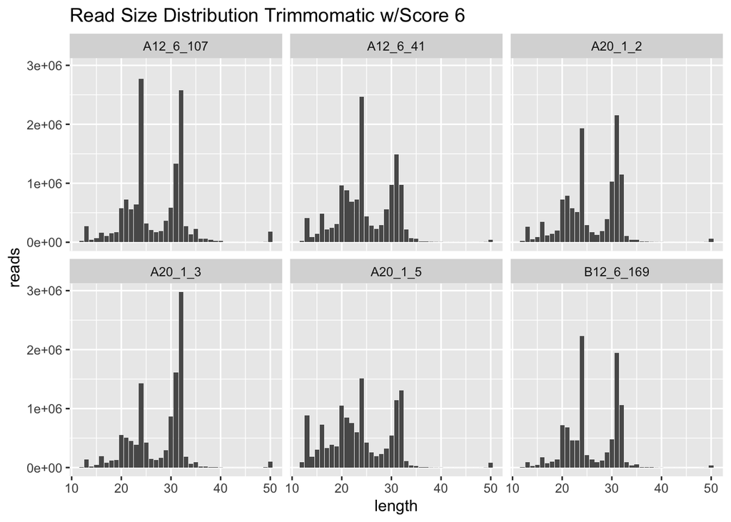

```r
library(tidyverse)
data6 <- read_csv("all_sizes_6.txt", col_names = FALSE, show_col_types = FALSE)
names(data6) <- c("reads", "length", "sample")

data6 %>% ggplot(aes(x = length, y = reads)) +
  geom_col() +
  facet_wrap(vars(sample)) +
  labs(title = "Read Size Distribution Trimmomatic w/Score 6")
```

### Number Seqs Remaining With Adaptor

Getting a rough estimate here of the number of sequences remaining in each file that might have adaptor sequence.

```bash
zcat trimmed_fastq2/A12_6_107.fq.gz | grep 'AGATCGGAAGA' | wc -l
7677
```

### Summary

The adaptor used by Novogene appears to be “AGATCGGAAGAGCACACGTCTGAACTCCAGTCAC”. Dropping the threshold score in Trimmomatic to 6 seems to help given the short reads. Looks like most seqs with adaptors have been trimmed, and read size distributions look reasonable, so can move forward with these datasets.

## Shortstack Analysis/Alignment

### Run Shortstack

```bash
#script 9_get_shortstack.sh
#first had to download/install viennarna and create a module for it.

curl -L -o shortstack.pl https://raw.githubusercontent.com/MikeAxtell/ShortStack/master/ShortStack

#script 12_run_shortstack.job

#PBS -l walltime=24:00:00
#PBS -l nodes=1:ppn=3
#PBS -A PAS1755
#PBS -j oe

cd $PBS_O_WORKDIR

module use $HOME/local/share/lmodfiles
module load viennarna/2.5.0
module load samtools
module load bowtie1/1.1.2

perl shortstack.pl --readfile trimmed_fastq2/A12_6_107.fq.gz trimmed_fastq2/A12_6_41.fq.gz trimmed_fastq2/A20_1_2.fq.gz trimmed_fastq2/A20_1_3.fq.gz trimmed_fastq2/A20_1_5.fq.gz trimmed_fastq2/B12_6_169.fq.gz --genomefile ref/Prunus_dulcis_Nonpareil_2.fa

#Results are in dir /fs/scratch/PAS1755/sovic/shortstack/ShortStack_1644852191
```

### Numbers of Seqs Aligned: Results.txt

These are seqs that were uniquely assigned to bins identified by Shortstack.

```bash
wc -l Results.txt
40722
```

### Preview: Results.txt

```r
ss_results <- read_tsv("Results.txt", show_col_types = FALSE)
knitr::kable(head(ss_results))
```

| #Locus | Name | Length | Reads | RPM | UniqueReads | FracTop | Strand | MajorRNA | MajorRNAReads | Complexity | DicerCall | MIRNA | PhaseScore | Short | Long | 20 | 21 | 22 | 23 | 24 |
| --- | --- | --- | --- | --- | --- | --- | --- | --- | --- | --- | --- | --- | --- | --- | --- | --- | --- | --- | --- | --- |
| chr1:7935-8061 | Cluster_1 | 127 | 102 | 1.426 | 8 | 0.088 | - | CUAUAUAUCUGAGAACCUAAUAUC | 66 | 0.157 | 24 | N11 | -1.0 | 0 | 0 | 1 | 2 | 4 | 5 | 90 |
| chr1:10482-10612 | Cluster_2 | 131 | 66 | 0.922 | 3 | 0.000 | - | AGCCGAUAUAUGAGAACACAACAU | 36 | 0.273 | 24 | N11 | -1.0 | 0 | 1 | 2 | 0 | 1 | 6 | 56 |
| chr1:11293-11349 | Cluster_3 | 57 | 81 | 1.132 | 69 | 0.086 | - | CUGUAUAUCUGAGAACCCAACAUC | 37 | 0.259 | 24 | N11 | -1.0 | 3 | 0 | 0 | 1 | 1 | 7 | 69 |
| chr1:12099-12671 | Cluster_4 | 573 | 63 | 0.881 | 33 | 0.333 | . | AACAUCUUACCCGCAAUUUAUGGA | 11 | 0.587 | 24 | N5 | 0.4 | 3 | 2 | 3 | 2 | 4 | 11 | 38 |
| chr1:29565-29719 | Cluster_5 | 155 | 38 | 0.531 | 1 | 0.947 | + | ACUCUGGUAAAUCUGAACAAAACC | 12 | 0.421 | 24 | N11 | -1.0 | 0 | 0 | 0 | 0 | 1 | 12 | 25 |
| chr1:45567-45657 | Cluster_6 | 91 | 68 | 0.950 | 5 | 0.088 | - | AAAGGCCUAUAUAUCUGAAAAUGC | 12 | 0.265 | 24 | N11 | -1.0 | 0 | 3 | 0 | 0 | 1 | 9 | 55 |

### Numbers of Seqs Aligned: Unplaced.txt

These are seqs that were assigned to multiple bins by Shortstack.

```bash
wc -l Unplaced.txt
19858
```

### Preview: Unplaced.txt

```r
unplaced <- read_tsv("Unplaced.txt", show_col_types = FALSE)
knitr::kable(head(unplaced))
```

| #RNA | Length | Reads | RPM | N_hits |
| --- | --- | --- | --- | --- |
| AAAAGGACUUUG | 12 | 62 | 0.867 | >50 |
| AAACUUAAAGGA | 12 | 61 | 0.853 | >50 |
| AAGGACUUUGAA | 12 | 39 | 0.545 | >50 |
| AAGGCUGAAACU | 12 | 38 | 0.531 | >50 |
| AAUGACUUGAGA | 12 | 46 | 0.643 | >50 |
| AAUUGCAGAAUC | 12 | 186 | 2.600 | >50 |

### Number of Seqs Aligned: Counts.txt

This includes results from both the Results.txt and Unplaced.txt files.

```bash
wc -l Counts.txt
60579 Counts.txt
```

### Preview: Counts.txt

```r
counts <- read_tsv("Counts.txt", show_col_types = FALSE)
knitr::kable(head(counts))
```

| Locus | Name | main | A12_6_107 | A12_6_41 | A20_1_2 | A20_1_3 | A20_1_5 | B12_6_169 |
| --- | --- | --- | --- | --- | --- | --- | --- | --- |
| chr1:7935-8061 | Cluster_1 | 102 | 14 | 21 | 31 | 9 | 2 | 25 |
| chr1:10482-10612 | Cluster_2 | 66 | 3 | 7 | 23 | 10 | 11 | 12 |
| chr1:11293-11349 | Cluster_3 | 81 | 19 | 14 | 21 | 8 | 6 | 13 |
| chr1:12099-12671 | Cluster_4 | 63 | 16 | 7 | 14 | 8 | 8 | 10 |
| chr1:29565-29719 | Cluster_5 | 38 | 6 | 6 | 11 | 9 | 2 | 4 |
| chr1:45567-45657 | Cluster_6 | 68 | 10 | 10 | 18 | 14 | 9 | 7 |

```r
knitr::kable(tail(counts))
```

| Locus | Name | main | A12_6_107 | A12_6_41 | A20_1_2 | A20_1_3 | A20_1_5 | B12_6_169 |
| --- | --- | --- | --- | --- | --- | --- | --- | --- |
| UUUCAAUGAUGAUCUACUUUCCCGUGUUGCUGAGUACAAAGUGACUGAUA | NA | 49 | 0 | 0 | 0 | 0 | 49 | 0 |
| UUUCAUGAUGAGUUAACACAUUUAUACGCUAUGCUGAACCAUACCAUGCG | NA | 270 | 0 | 0 | 0 | 0 | 270 | 0 |
| UUUCUAUGAUGAAUCAAACUAGCUCACUAUGACUGCUAAUGAAAACACAG | NA | 71 | 7 | 5 | 0 | 52 | 5 | 2 |
| UUUCUGUGAUGAAUCAACUAGCUCACUAUGACUGCUAAUGAAAACACUGG | NA | 54 | 5 | 2 | 4 | 1 | 41 | 1 |
| UUUGAUGAUGAUUUGCUUUUGGUCCGUGUUGCUGAUACAAAGUGACUGAA | NA | 77 | 0 | 0 | 0 | 0 | 77 | 0 |
| UUUGCAUGAUGACUUGAAUUGUCGGAUACCCCUUCACCCCGUUCAUGGGU | NA | 697 | 4 | 7 | 16 | 663 | 4 | 3 |

### Summary

This Shortstack run was with default parameters. Shortstack provides a number of result files. Results.txt, Unplaced.txt, and Counts.txt seem to be the primary ones. It appears the Results.txt file contains results for sequences that could be confidently assigned to a single location in the genome (uniquely mapped). These are placed into bins and each bin is annotated in the Results file with a consensus sequence. Shortstack also keeps track of other small RNAs. These are reported in a separate file “Unplaced.txt”, and each individual sequence is reported separately. The “Counts.txt” file has read counts for each sample for each sequence, and includes unplaced seqs.

## Blast Aligned Seqs To miRBase (7 Species)

Here we’re getting the sequences associated with the two aligned files (Results.txt and Unplaced.txt) and blasting them to a filtered version of the “mature.fa” database from mirBase, which was filtered to include Prunus, Arabidopsis, Malus, Glycine, Medicago, Populus, and Solanum. Used the parameters “-evalue 1 -task blastn-short -word_size 4 -gapopen 25 -gapextend 10 -reward 5 -penalty -4 -dust no -soft_masking false”, which I think are equivalent to doing a Blast search through the miR website, with the exception that the evalue is set to 1 here instead of 10 online. I think 1 is still pretty liberal, so we’ll apply additional filters below.

### Get Seqs To Blast

```bash
#script 6_get_results_to_blast.sh
grep -v '#' ShortStack_1644852191/Results.txt | cut -f1,9 > temp_res.txt

#script 7_Results_to_blast.pl (puts seqs from Results.txt into fasta format)

#! /usr/bin/perl
use warnings;
use strict;

open IN, "temp_res.txt" or die$!;
open OUT, ">Results_to_blast.fa";

my $name;
my $seq;

while(<IN>) {

      my @temp = split (/\t/, "$_");
      print OUT ">$temp[0]\n";
      print OUT "$temp[1]";

}

#script 8_Unplaced_to_blast.pl (puts seqs from Unplaced.txt into fasta format)

#! /usr/bin/perl
use warnings;
use strict;

open IN, "ShortStack_1644852191/Unplaced.txt" or die$!;
open OUT, ">Unplaced_to_blast.fa";

while(<IN>) {

        if ($_ =~ /^\#/) {
                next;
        }

        else {
                my @temp = split (/\t/, "$_");
                my $seq = $temp[0];
                print OUT ">$seq\n";
                print OUT "$seq\n";
        }

}

#script 9_cat_blast_input.sh
cat Results_to_blast.fa Unplaced_to_blast.fa > all_blast_input.fa
```

### Preview Blast Input

`head all_blast_input.fa`

>chr1:7935-8061 CUAUAUAUCUGAGAACCUAAUAUC

>chr1:10482-10612 AGCCGAUAUAUGAGAACACAACAU

>chr1:11293-11349 CUGUAUAUCUGAGAACCCAACAUC

>chr1:12099-12671 AACAUCUUACCCGCAAUUUAUGGA

>chr1:29565-29719 ACUCUGGUAAAUCUGAACAAAACC

`tail all_blast_input.fa`

>UUUCAUGAUGAGUUAACACAUUUAUACGCUAUGCUGAACCAUACCAUGCG UUUCAUGAUGAGUUAACACAUUUAUACGCUAUGCUGAACCAUACCAUGCG >UUUCUAUGAUGAAUCAAACUAGCUCACUAUGACUGCUAAUGAAAACACAG UUUCUAUGAUGAAUCAAACUAGCUCACUAUGACUGCUAAUGAAAACACAG >UUUCUGUGAUGAAUCAACUAGCUCACUAUGACUGCUAAUGAAAACACUGG UUUCUGUGAUGAAUCAACUAGCUCACUAUGACUGCUAAUGAAAACACUGG >UUUGAUGAUGAUUUGCUUUUGGUCCGUGUUGCUGAUACAAAGUGACUGAA UUUGAUGAUGAUUUGCUUUUGGUCCGUGUUGCUGAUACAAAGUGACUGAA >UUUGCAUGAUGACUUGAAUUGUCGGAUACCCCUUCACCCCGUUCAUGGGU UUUGCAUGAUGACUUGAAUUGUCGGAUACCCCUUCACCCCGUUCAUGGGU

### Create Blast Database

Downloaded “mature.fa” file, from mirBase, filtered for the 7 target species, and used it to create a blast database.

```bash
#script 10_get_mirBase.sh (download the mature miRs database from mirBase)
curl -L -o mirBase_mature.fa.gz https://www.mirbase.org/ftp/CURRENT/mature.fa.gz
gunzip mirBase_mature.fa.gz


#script 11_extract_targets.pl (filter the database file for the 7 target species)
#! /usr/bin/perl
use warnings;
use strict;

my $TargetSeq = "no";
my $print = "no";

open IN, "mirBase_mature.fa" or die$!;
open OUT, ">Targets_miRBase.fa";

while(<IN>) {

        if ($_ =~ /(>.+Prunus.+)|(>.+Arabidopsis.+)|(>.+Malus.+)|(>.+Glycine.+)|(>.+Medicago.+)|(>.+Populus.+)|(>.+Solanum.+)/) {
                $print = "yes";
                print OUT "$_";
        }

        elsif ($_ =~ />/) {
                $print = "no";
        }

        else {
                if ($print eq "yes") {
                        print OUT "$_";
                }
        }

}

#script 12_make_blast_db.sh

mkdir blast_db
module load blast
makeblastdb -dbtype nucl -in Targets_miRBase.fa -out blast_db/Targets_miRBase
```

### Run Blast (blastn-short)

Ran blastn (Blast version 2.10.0+) with parameters equivalent to an online Blast through mirBase website.

```bash
#script 19_blast_short_all_w_seqs_slen.job

#PBS -l walltime=03:00:00
#PBS -l nodes=1:ppn=2
#PBS -A PAS1755
#PBS -j oe

cd $PBS_O_WORKDIR

module load blast
blastn -evalue 1 -task blastn-short -word_size 4 -gapopen 25 -gapextend 10 -reward 5 -penalty -4 -dust no -soft_masking false -db blast_db/Targets_miRBase -query all_blast_input.fa -out blast_out_all_seqs_eval1.txt -outfmt "6 qseqid sseqid qstart qend sstart send evalue length pident qseq sseq slen length"
```

### Filter and Preview Blast Results

The Blast parameters we used that mimic a mirBase blast are fairly liberal, so further filtering here to retain only Blast hits at least as long as the relevant mature miR minus 2.

```r
blast_res <- read_tsv("blast_out_all_seqs_eval1.txt", col_names = FALSE)
names(blast_res) <- c("query", "subject", "qstart", "qend", "sstart", "send", "evalue", "length", "pct_identity", "qseq", "sseq", "slen")
blast_res <- blast_res %>% mutate("align_len" = stringr::str_length(sseq))
dim(blast_res)
```

```
## [1] 28615    13
```

```r
blast_res <- blast_res %>%
  dplyr::filter(align_len >= slen-2)
 # dplyr::filter(evalue <= 0.01) %>%
dim(blast_res)
```

```
## [1] 8959   13
```

```r
knitr::kable(head(blast_res))
```

| query | subject | qstart | qend | sstart | send | evalue | length | pct_identity | qseq | sseq | slen | align_len |
| --- | --- | --- | --- | --- | --- | --- | --- | --- | --- | --- | --- | --- |
| chr1:341533-341667 | gma-miR4414a-5p | 7 | 24 | 3 | 20 | 0.52 | 18 | 83.333 | CTGCTGAACCGTTGGATC | CTGCTGACTCGTTGGCTC | 20 | 18 |
| chr1:389739-389759 | ptc-miR7813 | 1 | 21 | 21 | 1 | 0.85 | 21 | 76.190 | TCATCAACACTTGTAGTAGCA | TTAGCAACACTTGCATTACCA | 21 | 21 |
| chr1:404154-404272 | mtr-miR5212-5p | 2 | 21 | 1 | 20 | 0.43 | 20 | 80.000 | TGTATTTTGTAGTTCTTTAG | TGGATTTCGTATTTCTTTGG | 22 | 20 |
| chr1:770181-770340 | stu-miR172e-5p | 4 | 24 | 21 | 1 | 0.92 | 21 | 76.190 | TGTTAACTTTGATGACGTGGC | TGTGAATCTTGATGATGTTGC | 21 | 21 |
| chr1:885314-885959 | gma-miR1521a | 7 | 24 | 1 | 18 | 0.52 | 18 | 83.333 | CTGTTGAAGGAAAATGGT | CTGTTAATGGAAAATGTT | 20 | 18 |
| chr1:993114-993860 | gma-miR4363 | 1 | 21 | 2 | 22 | 0.16 | 21 | 80.952 | GATAACCTGAAGGACTATTAG | GATTACCAGAAGGCTTATTAG | 22 | 21 |

### Extract Best Hit For Each Query

A given query sequence could have multiple valid Blast hits (valid hits to multiple species, etc). If multiple hits share the best evalue for a given query (a tie), each hit will be listed in the “hits” column. Then filter to just retain the best evalue for each query sequence.

```r
#summarize on query and evalue and create column with all subjects with that eval
#then arrange and distinct on query and evalue to retain the best one.

blast_sum <- blast_res %>%
   group_by(query, evalue) %>%
   summarize("hits" = paste(subject, collapse = "; "),
             "length" = paste(length, collapse = "; "),
             "pct_iden" = paste(pct_identity, collapse = "; "),
             "query_seq" = paste(qseq, collapse = "; "),
             "db_seq" = paste(sseq, collapse = "; "),
             "db_len" = paste(slen, collapse = "; "),
             "align_len" = paste(align_len, collapse = "; "))
#distinct to just retain the best evalue for each query
blast_sum_filt <- blast_sum %>%
  arrange(query, evalue) %>%
  distinct(query, .keep_all = TRUE)
```

## Differential Expression (DESeq) Analysis

### Preview Counts Table From Shortstack

Using the Counts.txt file from Shortstack as input, which includes read counts for each sample for each small RNA identified, including unplaced sequences (multiple mappers).

### Prep Data

```r
library(DESeq2)
library(RColorBrewer)

counts <- read_tsv(file = "Counts.txt", col_names = TRUE, col_types = "cciiiiiii")
samples<-read_tsv(file="samples.txt", col_names = TRUE, show_col_types = FALSE)

counts_matrix <- counts %>%
  dplyr::select(4:9) %>% as.matrix()

se <- SummarizedExperiment(assays = counts_matrix, colData = samples)
se@elementMetadata@rownames <- counts$Locus
dds <- DESeqDataSet(se, design = ~age)
```

### Perform DE Analysis For 6yr vs 1yr Expression Levels

```r
fitAge<-DESeq(dds)
DEG_res <- results(fitAge, alpha = 0.1, contrast=c("age", "6yr", "1yr"))
DEG_res <- data.frame(DEG_res, row.names = rownames(DEG_res))
DEG_res <- DEG_res %>% mutate("ID" = se@elementMetadata@rownames)

#Join the Blast hits in to the DE results by sequence ID
blast_sum_filt <- blast_sum_filt  %>%
  rename("query" = "ID",
         "hits" = "blast_hits")
DEG_res <- left_join(x = DEG_res, y = blast_sum_filt, by = "ID")
```

### Add Columns To DE Results

- seq: The sequences originally coming from the Unplaced.txt file are identified by their sequence, but those coming from the Results.txt file (uniquely aligned) are identified by their genome coordinates, so adding in a column that stores the sequence for each.

```r
results_seqs <- read_tsv("Results.txt") %>% dplyr::select(1,9)
names(results_seqs) <- c("ID", "seq")
DEG_res <- left_join(x = DEG_res, y = results_seqs, by = "ID")
DEG_res$seq[is.na(DEG_res$seq)] <- DEG_res$ID[is.na(DEG_res$seq)]
```

### Mark Significant miRs and Get -log10p For Volcano Plot

- ‘-log10p’: negative log10(padj) to be used for volcano plot
- sig: Identifies significant small RNAs, defined as padj < 0.01 and an absolute Log2FoldChange > 2.
- miR_family: for small RNAs with a Blast hit, the name of the miR they Blasted to is edited to reflect the miR family. For example, miR156a and miR156b would both be assigned to miR156.

```r
DEG_res <- DEG_res %>%
  mutate("-log10p" = -log10(padj),
         "sig" = ifelse((padj < 0.01 & (abs(log2FoldChange) > 2)), "Y", "N"),
         "miR_family" = stringr::str_remove(blast_hits, ";.+"))

DEG_res$miR_family <- stringr::str_remove(DEG_res$miR_family, "...-")
DEG_res$miR_family <- stringr::str_remove(DEG_res$miR_family, "-[35]p")
DEG_res$miR_family <- stringr::str_remove(DEG_res$miR_family, "[a-z]$")
DEG_res$miR_family <- stringr::str_remove(DEG_res$miR_family, "^\\s")
```

### Write Results Table To File

This file has DE analysis results (including padj and log2fold change) for all analyzed small RNAs. Rows with an entry in the “ID” column that has genome coordinates represent sequences that aligned uniquely (grouped into bins by Shortstack with consensus sequence). If the “ID” column has a sequence, it’s a small RNA that Shortstack identified, but was unplaced. Each unique unplaced sequence is reported separately. Positive log2 fold changes indicate upregulation in 6yr samples with respect to 1yr samples.

For the small RNAs associated with a Blast hit(s) that passed the filtering, those blast hits are included, along with the identity of the sequence that was Blasted (column “seq”; sequence from Shortstack), the aligned portion of the sequence that was Blasted (column “query seq”), and the aligned portion of the sequence from miRbase (mature miR) the sequence Blasted to (column “db_seq”).

```r
write.table(DEG_res, file = "all_DE_results_w_aligned_seqs.csv", sep = ",", quote = FALSE, col.names = TRUE, row.names = FALSE)
```

### PCA Plot

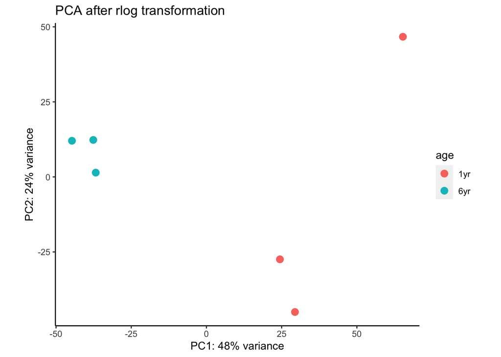

```r
rld<-rlogTransformation(dds, blind=FALSE)
pcaData <- plotPCA(rld, intgroup = c("age"), returnData = TRUE)
percentVar <- round(100 * attr(pcaData, "percentVar"))

ggplot(pcaData, aes(x = PC1, y = PC2, color = age)) +
  ggtitle("PCA after rlog transformation") + geom_point(size =3) + xlab(paste0("PC1: ", percentVar[1], "% variance")) +
  ylab(paste0("PC2: ", percentVar[2], "% variance")) + coord_fixed() + theme(panel.grid.major = element_blank(), panel.grid.minor = element_blank(), panel.background = element_blank(), axis.line = element_line(colour = "black"))
```

### Volcano Plot - All Small RNAs

This plot represents all analyzed small RNAs identified by Shortstack (n = 60578). Significance reflects padj < 0.01 & abs(log2foldchange) > 2. Note there are a few points that are intentionally cut off here with a l2fc ~-20.

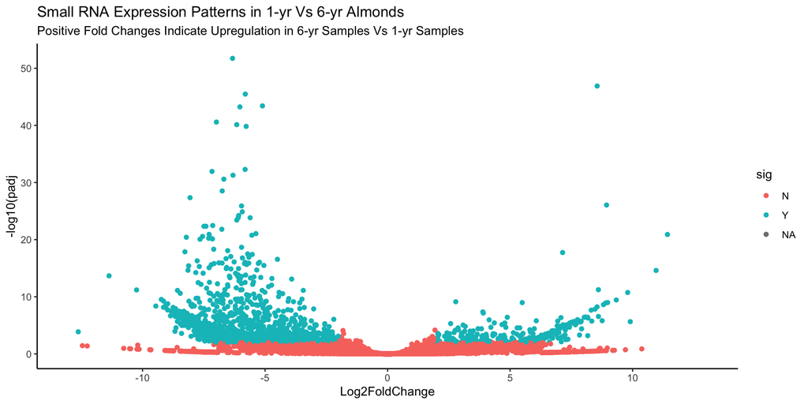

```r
ggplot(DEG_res, aes(x = log2FoldChange, y = `-log10p`, color = sig)) +
  geom_point() +
  theme_classic() +
  labs(y = "-log10(padj", x = "Log2FoldChange",
       title = "Small RNA Expression Patterns in 1-yr Vs 6-yr Almonds",
       subtitle = "Positive Fold Changes Indicate Upregulation in 6-yr Samples Vs 1-yr Samples") +
  coord_cartesian(xlim = c(-13, 13))
```

```r
#note there are a few points that are intentionally cut off here with a l2fc ~-20.
```

### Volcano Plot - Assigned miRs

This volcano plot has data for only the set of small RNAs that were assigned confidently to a mature miR from miRbase (Blast evalue < 0.1 & aligned length >= (mature miR length - 2)). There are 455 of these (out of the 60578 total small RNAs identified by Shortstack). Those with a padj value <=0.01 are colored based on their miR family (i.e. miR156a & miR156b would be grouped into miR156). These colored points cover a lot of the miR families identified in the “DE miR family” analysis below that are robust to evalue thresholds.

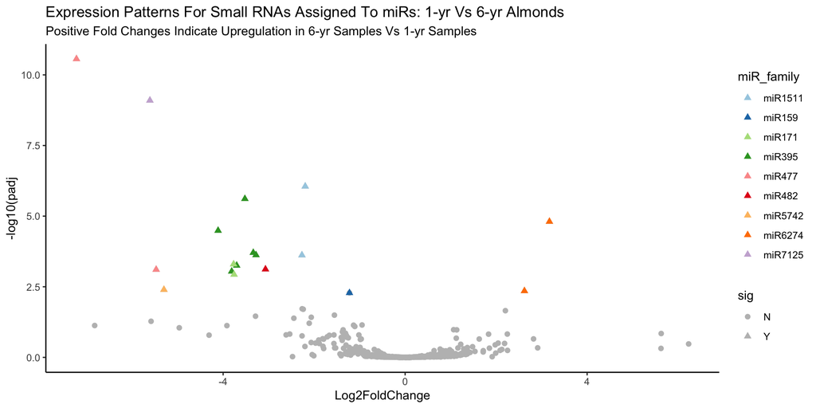

```r
#split the data into two data frames - one with points that will be colored, and one with all other points.

to_color <- DEG_res %>%
  dplyr::filter(!is.na(padj)) %>%
  dplyr::filter(evalue <= 0.1) %>%
  dplyr::filter(padj <= 0.01) %>%
  dplyr::select(log2FoldChange, `-log10p`, padj, sig, miR_family)

not_colored <- DEG_res %>%
  dplyr::filter(!is.na(padj)) %>%
  dplyr::filter(evalue < 0.1) %>%
  #dplyr::filter(padj > 0.01) %>%
  dplyr::select(log2FoldChange, `-log10p`, padj, sig, miR_family)

ggplot(not_colored %>% filter(!is.na(sig)), aes(x = log2FoldChange, y = `-log10p`, shape = sig))  +
  geom_point(size = 2, color = "gray") +
  theme_classic() +
  labs(y = "-log10(padj", x = "Log2FoldChange",
       title = "Expression Patterns For Small RNAs Assigned To miRs: 1-yr Vs 6-yr Almonds",
       subtitle = "Positive Fold Changes Indicate Upregulation in 6-yr Samples Vs 1-yr Samples")  +
  scale_color_brewer(palette = "Paired") +
  geom_point(data = to_color, aes(x = log2FoldChange, y = `-log10p`, color = miR_family), inherit.aes = FALSE, shape = 17, size = 2)
```

## Overlap Analysis

Katie sent the coordinates for the 17 DMRs they identified. This analysis compares each of those to the set of coordinates associated with uniquely mapped differentially expressed small RNAs identified from the Shortstack/DEseq analysis to see if there is any overlap.

In each analysis below, if the sum is 1, then the query region (Katie’s DMR) overlaps with at least one of the DE miR regions by at least one bp. A sum of zero indicates no overlap. The “buffer” argument pads the target coordinates (in this case, the DE miRs) by the given value on each side.

```r
contains_func <- function(target, query, buffer = 0) {
  target_chr <- stringr::str_remove(target, ":.+")
  query_chr <- stringr::str_remove(query, ":.+")

  target_min <- stringr::str_replace(target, "(.+:)(.+)(-.+)", "\\2") %>% as.integer()
  target_max <- stringr::str_replace(target, "(.+:)(.+-)(.+)", "\\3") %>% as.integer()
  target_min <- target_min - buffer
  target_max <- target_max + buffer
  target_range <- target_min:target_max

  query_min <- stringr::str_replace(query, "(.+:)(.+)(-.+)", "\\2") %>% as.integer()
  query_max <- stringr::str_replace(query, "(.+:)(.+-)(.+)", "\\3") %>% as.integer()
  query_range <- query_min:query_max

  query_in_target <- ifelse(sum(query_range %in% target_range) > 0, "Y", "N")
  chr_match <- ifelse(target_chr == query_chr, "Y", "N")

  match <- ifelse(query_in_target == "Y" & chr_match == "Y", 1, 0)
  match
}

sig_inputs <- DEG_res %>%
  dplyr::filter(sig == "Y") %>%
  dplyr::filter(grepl("chr", ID)) %>% pull(ID)

#chr8:9988937-9988940 (test - these coordinates are taken from one of the DE genes, and serve as a positive control)
out <- sapply(sig_inputs, contains_func, query = "chr8:9988937-9988940", buffer = 10000)
sum(out)
```

```
## [1] 1
```

```r
#chr6:11481648-11484599
out <- sapply(sig_inputs, contains_func, query = "chr6:11481648-11484599", buffer = 10000)
sum(out)
```

```
## [1] 0
```

```r
#chr6:5122822-5124703
out <- sapply(sig_inputs, contains_func, query = "chr6:5122822-5124703", buffer = 10000)
sum(out)
```

```
## [1] 0
```

```r
#chr8:14686870-14697541
out <- sapply(sig_inputs, contains_func, query = "chr8:14686870-14697541", buffer = 10000)
sum(out)
```

```
## [1] 0
```

```r
#chr1:36988003-36989001
out <- sapply(sig_inputs, contains_func, query = "chr1:36988003-36989001", buffer = 10000)
sum(out)
```

```
## [1] 0
```

```r
#chr1:17181984-17183843
out <- sapply(sig_inputs, contains_func, query = "chr1:17181984-17183843", buffer = 10000)
sum(out)
```

```
## [1] 0
```

```r
#chr7:7732940-7736793
out <- sapply(sig_inputs, contains_func, query = "chr7:7732940-7736793", buffer = 10000)
sum(out)
```

```
## [1] 0
```

```r
#chr2:12422670-12423066
out <- sapply(sig_inputs, contains_func, query = "chr2:12422670-12423066", buffer = 10000)
sum(out)
```

```
## [1] 0
```

```r
#chr6:3439053-3439763
out <- sapply(sig_inputs, contains_func, query = "chr6:3439053-3439763", buffer = 10000)
sum(out)
```

```
## [1] 0
```

```r
#chr8:7299785-7304401
out <- sapply(sig_inputs, contains_func, query = "chr8:7299785-7304401", buffer = 10000)
sum(out)
```

```
## [1] 0
```

```r
#chr8:21331964-21333852
out <- sapply(sig_inputs, contains_func, query = "chr8:21331964-21333852", buffer = 10000)
sum(out)
```

```
## [1] 0
```

```r
#chr8:7041990-7043388
out <- sapply(sig_inputs, contains_func, query = "chr8:7041990-7043388", buffer = 10000)
sum(out)
```

```
## [1] 0
```

```r
#chr8:5019298-5021435
out <- sapply(sig_inputs, contains_func, query = "chr8:5019298-5021435", buffer = 10000)
sum(out)
```

```
## [1] 0
```

```r
#chr1:1101269-1101943
out <- sapply(sig_inputs, contains_func, query = "chr1:1101269-1101943", buffer = 10000)
sum(out)
```

```
## [1] 1
```

```r
#chr8:7202236-7205963
out <- sapply(sig_inputs, contains_func, query = "chr8:7202236-7205963", buffer = 10000)
sum(out)
```

```
## [1] 0
```

```r
#chr3:20612169-20614252
out <- sapply(sig_inputs, contains_func, query = "chr3:20612169-20614252", buffer = 10000)
sum(out)
```

```
## [1] 0
```

```r
#chr8:5019298-5021435
out <- sapply(sig_inputs, contains_func, query = "chr8:5019298-5021435", buffer = 10000)
sum(out)
```

```
## [1] 0
```

```r
#chr1:34468253-34469756
out <- sapply(sig_inputs, contains_func, query = "chr1:34468253-34469756", buffer = 10000)
sum(out)
```

```
## [1] 0
```

```r
out <- sapply(sig_inputs, contains_func, query = "chr1:1101269-1101943", buffer = 8500)
sum(out)
```

```
## [1] 1
```

```r
out <- sapply(sig_inputs, contains_func, query = "chr1:1101269-1101943", buffer = 8000)
sum(out)
```

```
## [1] 0
```

### DMR Overlap Summary

Using the coordinates Katie provided, there’s no overlap with any of the 321 uniquely mapped DE miRs. Adding a buffer of 8500 bp on each side returns an overlap for a single DMR: chr1:1101269-1101943. This DMR overlaps with miR chr1:1092841-1093180…

```r
knitr::kable(DEG_res %>% filter(ID == "chr1:1092841-1093180"))
```

| baseMean | log2FoldChange | lfcSE | stat | pvalue | padj | ID | evalue | blast_hits | length | pct_iden | query_seq | db_seq | db_len | align_len | seq | -log10p | sig | miR_family |
| --- | --- | --- | --- | --- | --- | --- | --- | --- | --- | --- | --- | --- | --- | --- | --- | --- | --- | --- |
| 93.51638 | 3.623938 | 0.9876418 | 3.669283 | 0.0002432 | 0.0083879 | chr1:1092841-1093180 | NA | NA | NA | NA | NA | NA | NA | NA | AAUAGACUUGUGCUGACACGUGGC | 2.076346 | Y | NA |

## Pull Out Unique DE miR Families

This analysis groups miRs identified in the Blast analysis into families (i.e. miR156a and miR156b get grouped into miR156) and then identifies the unique families associated with significant DE miRs. Running for different combinations of evalue threshold and Blast databases. For each combination, pulled out the shared miRs (overlaps) between the analysis with just the Blast to Prunus and the analysis with the Blast to the 7 species (including Prunus).

### Perform DE Analysis For 6yr vs 1yr Expression Levels

```r
fitAge<-DESeq(dds)
DEG_res2 <- results(fitAge, alpha = 0.1, contrast=c("age", "6yr", "1yr"))
DEG_res2 <- data.frame(DEG_res2, row.names = rownames(DEG_res))
DEG_res2 <- DEG_res2 %>% mutate("ID" = se@elementMetadata@rownames)
```

### Write Function

```r
uniq_deg_fams <- function(blast_results, max_eval, maxp, min_l2fc) {

blast_res <- read_tsv(blast_results, col_names = FALSE)
names(blast_res) <- c("query", "subject", "qstart", "qend", "sstart", "send", "evalue", "length", "pct_identity", "qseq", "sseq", "slen")
blast_res <- blast_res %>%
  mutate("align_len" = stringr::str_length(sseq))

blast_res <- blast_res %>%
  dplyr::filter(align_len >= slen-2) %>%
  dplyr::filter(evalue <= max_eval)

blast_sum <- blast_res %>%
   group_by(query, evalue) %>%
   summarize("hits" = paste(subject, collapse = "; "),
             "length" = paste(length, collapse = "; "),
             "pct_iden" = paste(pct_identity, collapse = "; "),
             "query_seq" = paste(qseq, collapse = "; "),
             "db_seq" = paste(sseq, collapse = "; "),
             "db_len" = paste(slen, collapse = "; "),
             "align_len" = paste(align_len, collapse = "; "))

#distinct to just retain the best evalue for each query
blast_sum_filt <- blast_sum %>%
  arrange(query, evalue) %>%
  distinct(query, .keep_all = TRUE)

#Join the Blast hits in to the DE results by sequence ID
blast_sum_filt <- blast_sum_filt  %>%
  rename("query" = "ID",
         "hits" = "blast_hits")
DEG_res3 <- left_join(x = DEG_res2, y = blast_sum_filt, by = "ID")

results_seqs <- read_tsv("Results.txt") %>% dplyr::select(1,9)
names(results_seqs) <- c("ID", "seq")
DEG_res3 <- left_join(x = DEG_res3, y = results_seqs, by = "ID")
DEG_res3$seq[is.na(DEG_res3$seq)] <- DEG_res3$ID[is.na(DEG_res3$seq)]

sig_miRs <- DEG_res3 %>%
  filter(padj < maxp & abs(log2FoldChange) > min_l2fc) %>%
  filter(!is.na(blast_hits)) %>% pull(blast_hits) %>%
  stringr::str_split(";") %>% unlist() %>% stringr::str_remove("...-") %>%
  stringr::str_remove("-[35]p") %>%
  stringr::str_remove("[a-z]$") %>%
  stringr::str_remove("^\\s") %>%
  unique()

sig_miRs
}
```

### Target Species (7), Evalue 1

```r
all_e1 <- uniq_deg_fams(blast_results = "blast_out_all_seqs_eval1.txt", max_eval = 1, maxp = 0.01, min_l2fc = 2)

all_e1
```

```
##  [1] "miR169"   "miR841"   "miR395"   "miR2665"  "miR171"   "miR159"
##  [7] "miR6456"  "miR1511"  "miR477"   "miR7125"  "miR6274"  "miR5377"
## [13] "miR482"   "miR6470"  "miR5742"  "miR7992"  "miR9733"  "miR4397"
## [19] "miR5674"  "miR158"   "miR5234"  "miR8171"  "miR9755"  "miR402"
## [25] "miR2642"  "miR4361"  "miR6300"  "miR10432" "miR6299"  "miR5678"
## [31] "miR9728"
```

### Prunus Only, Evalue 1

```r
prunus_e1 <- uniq_deg_fams(blast_results = "blast_out_prunus_seqs_eval1.txt", max_eval = 1, maxp = 0.01, min_l2fc = 2)

prunus_e1
```

```
##  [1] "miR169"  "miR6288" "miR395"  "miR171"  "miR1511" "miR398"  "miR477"
##  [8] "miR399"  "miR6271" "miR7125" "miR482"  "miR6292" "miR6264" "miR8122"
## [15] "miR6274" "miR6287" "miR6291" "miR6277" "miR167"  "miR160"  "miR8131"
## [22] "miR393"  "miR8128" "miR403"  "miR6297" "miR828"  "miR6267" "miR8126"
## [29] "miR319"  "miR535"  "miR8127" "miR7122"
```

### Overlaps Evalue 1

```r
e1_shared <- all_e1[all_e1 %in% prunus_e1]
e1_shared
```

```
## [1] "miR169"  "miR395"  "miR171"  "miR1511" "miR477"  "miR7125" "miR6274"
## [8] "miR482"
```

### Target Species (7), Evalue 0.1

```r
all_e01 <- uniq_deg_fams(blast_results = "blast_out_all_seqs_eval1.txt", max_eval = 0.1, maxp = 0.01, min_l2fc = 2)

all_e01
```

```
## [1] "miR395"  "miR171"  "miR1511" "miR477"  "miR7125" "miR6274" "miR482"
## [8] "miR5742"
```

### Prunus Only, Evalue 0.1

```r
prunus_e01 <- uniq_deg_fams(blast_results = "blast_out_prunus_seqs_eval1.txt", max_eval = 0.1, maxp = 0.01, min_l2fc = 2)

prunus_e01
```

```
##  [1] "miR169"  "miR395"  "miR171"  "miR1511" "miR477"  "miR7125" "miR6264"
##  [8] "miR6274" "miR482"  "miR167"
```

### Overlaps Evalue 0.1

```r
e01_shared <- all_e01[all_e01 %in% prunus_e01]
e01_shared
```

```
## [1] "miR395"  "miR171"  "miR1511" "miR477"  "miR7125" "miR6274" "miR482"
```

### Target Species (7), Evalue 0.01

```r
all_e001 <- uniq_deg_fams(blast_results = "blast_out_all_seqs_eval1.txt", max_eval = 0.01, maxp = 0.01, min_l2fc = 2)

all_e01
```

```
## [1] "miR395"  "miR171"  "miR1511" "miR477"  "miR7125" "miR6274" "miR482"
## [8] "miR5742"
```

### Prunus Only, Evalue 0.01

```r
prunus_e001 <- uniq_deg_fams(blast_results = "blast_out_prunus_seqs_eval1.txt", max_eval = 0.01, maxp = 0.01, min_l2fc = 2)

prunus_e01
```

```
##  [1] "miR169"  "miR395"  "miR171"  "miR1511" "miR477"  "miR7125" "miR6264"
##  [8] "miR6274" "miR482"  "miR167"
```

### Overlaps Evalue 0.01

```r
e001_shared <- all_e001[all_e001 %in% prunus_e001]
e001_shared
```

```
## [1] "miR395"  "miR171"  "miR1511" "miR477"  "miR7125" "miR482"
```

### View Overlapping Results For Evalue 0.1

```r
knitr::kable(DEG_res %>%
               dplyr::filter(miR_family %in% e01_shared) %>%
               dplyr::filter(evalue <= 0.1) %>%
               dplyr::filter(abs(log2FoldChange) > 2) %>%
               dplyr::filter(padj < 0.01))
```

| baseMean | log2FoldChange | lfcSE | stat | pvalue | padj | ID | evalue | blast_hits | length | pct_iden | query_seq | db_seq | db_len | align_len | seq | -log10p | sig | miR_family |
| --- | --- | --- | --- | --- | --- | --- | --- | --- | --- | --- | --- | --- | --- | --- | --- | --- | --- | --- |
| 108.04344 | -3.521990 | 0.6231567 | -5.651854 | 0.0000000 | 0.0000024 | chr1:30729237-30729670 | 1.54e-04 | ppe-miR395n; ppe-miR395m; ppe-miR395l; ppe-miR395k; ppe-miR395j; ppe-miR395i; ppe-miR395h; ppe-miR395g; ppe-miR395f; ppe-miR395e; ppe-miR395d; ppe-miR395c; stu-miR395j; stu-miR395i; stu-miR395h; stu-m… | 21; 21; 21; 21; 21; 21; 21; 21; 21; 21; 21; 21; 21; 21; 21; 21; 21; 21; 21; 21; 21; 21; 21; 21; 21; 21; 21; 21; 21; 21; 21; 21; 21; 21; 21; 21; 21; 21; 21; 21; 21; 21; 21; 21; 21; 21; 21; 21; 21; 21; … | 100; 100; 100; 100; 100; 100; 100; 100; 100; 100; 100; 100; 100; 100; 100; 100; 100; 100; 100; 100; 100; 100; 100; 100; 100; 100; 100; 100; 100; 100; 100; 100; 100; 100; 100; 100; 100; 100; 100; 100; … | CTGAAGTGTTTGGGGGAACTC; CTGAAGTGTTTGGGGGAACTC; CTGAAGTGTTTGGGGGAACTC; CTGAAGTGTTTGGGGGAACTC; CTGAAGTGTTTGGGGGAACTC; CTGAAGTGTTTGGGGGAACTC; CTGAAGTGTTTGGGGGAACTC; CTGAAGTGTTTGGGGGAACTC; CTGAAGTGTTTGGGGG… | CTGAAGTGTTTGGGGGAACTC; CTGAAGTGTTTGGGGGAACTC; CTGAAGTGTTTGGGGGAACTC; CTGAAGTGTTTGGGGGAACTC; CTGAAGTGTTTGGGGGAACTC; CTGAAGTGTTTGGGGGAACTC; CTGAAGTGTTTGGGGGAACTC; CTGAAGTGTTTGGGGGAACTC; CTGAAGTGTTTGGGGG… | 21; 21; 21; 21; 21; 21; 21; 21; 21; 21; 21; 21; 21; 21; 21; 21; 21; 21; 21; 21; 21; 21; 21; 21; 21; 21; 21; 21; 21; 21; 21; 21; 21; 21; 21; 21; 21; 21; 22; 22; 21; 21; 21; 21; 21; 21; 21; 21; 21; 21; … | 21; 21; 21; 21; 21; 21; 21; 21; 21; 21; 21; 21; 21; 21; 21; 21; 21; 21; 21; 21; 21; 21; 21; 21; 21; 21; 21; 21; 21; 21; 21; 21; 21; 21; 21; 21; 21; 21; 21; 21; 21; 21; 21; 21; 21; 21; 21; 21; 21; 21; … | CUGAAGUGUUUGGGGGAACUC | 5.613704 | Y | miR395 |
| 51.75326 | -3.701581 | 0.8353987 | -4.430915 | 0.0000094 | 0.0005590 | chr1:30736468-30736529 | 1.54e-04 | ppe-miR395b-3p; ppe-miR395a-3p | 21; 21 | 100; 100 | CTGAAGTGTTTGGGGGGACCC; CTGAAGTGTTTGGGGGGACCC | CTGAAGTGTTTGGGGGGACCC; CTGAAGTGTTTGGGGGGACCC | 21; 21 | 21; 21 | CUGAAGUGUUUGGGGGGACCC | 3.252599 | Y | miR395 |
| 67.78960 | -3.337379 | 0.7101755 | -4.699372 | 0.0000026 | 0.0001966 | chr1:30751160-30751833 | 1.54e-04 | ppe-miR395n; ppe-miR395m; ppe-miR395l; ppe-miR395k; ppe-miR395j; ppe-miR395i; ppe-miR395h; ppe-miR395g; ppe-miR395f; ppe-miR395e; ppe-miR395d; ppe-miR395c; stu-miR395j; stu-miR395i; stu-miR395h; stu-m… | 21; 21; 21; 21; 21; 21; 21; 21; 21; 21; 21; 21; 21; 21; 21; 21; 21; 21; 21; 21; 21; 21; 21; 21; 21; 21; 21; 21; 21; 21; 21; 21; 21; 21; 21; 21; 21; 21; 21; 21; 21; 21; 21; 21; 21; 21; 21; 21; 21; 21; … | 100; 100; 100; 100; 100; 100; 100; 100; 100; 100; 100; 100; 100; 100; 100; 100; 100; 100; 100; 100; 100; 100; 100; 100; 100; 100; 100; 100; 100; 100; 100; 100; 100; 100; 100; 100; 100; 100; 100; 100; … | CTGAAGTGTTTGGGGGAACTC; CTGAAGTGTTTGGGGGAACTC; CTGAAGTGTTTGGGGGAACTC; CTGAAGTGTTTGGGGGAACTC; CTGAAGTGTTTGGGGGAACTC; CTGAAGTGTTTGGGGGAACTC; CTGAAGTGTTTGGGGGAACTC; CTGAAGTGTTTGGGGGAACTC; CTGAAGTGTTTGGGGG… | CTGAAGTGTTTGGGGGAACTC; CTGAAGTGTTTGGGGGAACTC; CTGAAGTGTTTGGGGGAACTC; CTGAAGTGTTTGGGGGAACTC; CTGAAGTGTTTGGGGGAACTC; CTGAAGTGTTTGGGGGAACTC; CTGAAGTGTTTGGGGGAACTC; CTGAAGTGTTTGGGGGAACTC; CTGAAGTGTTTGGGGG… | 21; 21; 21; 21; 21; 21; 21; 21; 21; 21; 21; 21; 21; 21; 21; 21; 21; 21; 21; 21; 21; 21; 21; 21; 21; 21; 21; 21; 21; 21; 21; 21; 21; 21; 21; 21; 21; 21; 22; 22; 21; 21; 21; 21; 21; 21; 21; 21; 21; 21; … | 21; 21; 21; 21; 21; 21; 21; 21; 21; 21; 21; 21; 21; 21; 21; 21; 21; 21; 21; 21; 21; 21; 21; 21; 21; 21; 21; 21; 21; 21; 21; 21; 21; 21; 21; 21; 21; 21; 21; 21; 21; 21; 21; 21; 21; 21; 21; 21; 21; 21; … | CUGAAGUGUUUGGGGGAACUC | 3.706492 | Y | miR395 |
| 37.98584 | -3.811832 | 0.8859704 | -4.302437 | 0.0000169 | 0.0009013 | chr1:30760000-30760138 | 1.54e-04 | ppe-miR395b-3p; ppe-miR395a-3p | 21; 21 | 100; 100 | CTGAAGTGTTTGGGGGGACCC; CTGAAGTGTTTGGGGGGACCC | CTGAAGTGTTTGGGGGGACCC; CTGAAGTGTTTGGGGGGACCC | 21; 21 | 21; 21 | CUGAAGUGUUUGGGGGGACCC | 3.045125 | Y | miR395 |
| 38.85000 | -3.277466 | 0.7046494 | -4.651201 | 0.0000033 | 0.0002381 | chr1:30765451-30765709 | 1.54e-04 | ppe-miR395n; ppe-miR395m; ppe-miR395l; ppe-miR395k; ppe-miR395j; ppe-miR395i; ppe-miR395h; ppe-miR395g; ppe-miR395f; ppe-miR395e; ppe-miR395d; ppe-miR395c; stu-miR395j; stu-miR395i; stu-miR395h; stu-m… | 21; 21; 21; 21; 21; 21; 21; 21; 21; 21; 21; 21; 21; 21; 21; 21; 21; 21; 21; 21; 21; 21; 21; 21; 21; 21; 21; 21; 21; 21; 21; 21; 21; 21; 21; 21; 21; 21; 21; 21; 21; 21; 21; 21; 21; 21; 21; 21; 21; 21; … | 100; 100; 100; 100; 100; 100; 100; 100; 100; 100; 100; 100; 100; 100; 100; 100; 100; 100; 100; 100; 100; 100; 100; 100; 100; 100; 100; 100; 100; 100; 100; 100; 100; 100; 100; 100; 100; 100; 100; 100; … | CTGAAGTGTTTGGGGGAACTC; CTGAAGTGTTTGGGGGAACTC; CTGAAGTGTTTGGGGGAACTC; CTGAAGTGTTTGGGGGAACTC; CTGAAGTGTTTGGGGGAACTC; CTGAAGTGTTTGGGGGAACTC; CTGAAGTGTTTGGGGGAACTC; CTGAAGTGTTTGGGGGAACTC; CTGAAGTGTTTGGGGG… | CTGAAGTGTTTGGGGGAACTC; CTGAAGTGTTTGGGGGAACTC; CTGAAGTGTTTGGGGGAACTC; CTGAAGTGTTTGGGGGAACTC; CTGAAGTGTTTGGGGGAACTC; CTGAAGTGTTTGGGGGAACTC; CTGAAGTGTTTGGGGGAACTC; CTGAAGTGTTTGGGGGAACTC; CTGAAGTGTTTGGGGG… | 21; 21; 21; 21; 21; 21; 21; 21; 21; 21; 21; 21; 21; 21; 21; 21; 21; 21; 21; 21; 21; 21; 21; 21; 21; 21; 21; 21; 21; 21; 21; 21; 21; 21; 21; 21; 21; 21; 22; 22; 21; 21; 21; 21; 21; 21; 21; 21; 21; 21; … | 21; 21; 21; 21; 21; 21; 21; 21; 21; 21; 21; 21; 21; 21; 21; 21; 21; 21; 21; 21; 21; 21; 21; 21; 21; 21; 21; 21; 21; 21; 21; 21; 21; 21; 21; 21; 21; 21; 21; 21; 21; 21; 21; 21; 21; 21; 21; 21; 21; 21; … | CUGAAGUGUUUGGGGGAACUC | 3.623188 | Y | miR395 |
| 21.13524 | -4.110762 | 0.8041934 | -5.111659 | 0.0000003 | 0.0000324 | chr1:30766802-30766917 | 1.54e-04 | ppe-miR395n; ppe-miR395m; ppe-miR395l; ppe-miR395k; ppe-miR395j; ppe-miR395i; ppe-miR395h; ppe-miR395g; ppe-miR395f; ppe-miR395e; ppe-miR395d; ppe-miR395c; stu-miR395j; stu-miR395i; stu-miR395h; stu-m… | 21; 21; 21; 21; 21; 21; 21; 21; 21; 21; 21; 21; 21; 21; 21; 21; 21; 21; 21; 21; 21; 21; 21; 21; 21; 21; 21; 21; 21; 21; 21; 21; 21; 21; 21; 21; 21; 21; 21; 21; 21; 21; 21; 21; 21; 21; 21; 21; 21; 21; … | 100; 100; 100; 100; 100; 100; 100; 100; 100; 100; 100; 100; 100; 100; 100; 100; 100; 100; 100; 100; 100; 100; 100; 100; 100; 100; 100; 100; 100; 100; 100; 100; 100; 100; 100; 100; 100; 100; 100; 100; … | CTGAAGTGTTTGGGGGAACTC; CTGAAGTGTTTGGGGGAACTC; CTGAAGTGTTTGGGGGAACTC; CTGAAGTGTTTGGGGGAACTC; CTGAAGTGTTTGGGGGAACTC; CTGAAGTGTTTGGGGGAACTC; CTGAAGTGTTTGGGGGAACTC; CTGAAGTGTTTGGGGGAACTC; CTGAAGTGTTTGGGGG… | CTGAAGTGTTTGGGGGAACTC; CTGAAGTGTTTGGGGGAACTC; CTGAAGTGTTTGGGGGAACTC; CTGAAGTGTTTGGGGGAACTC; CTGAAGTGTTTGGGGGAACTC; CTGAAGTGTTTGGGGGAACTC; CTGAAGTGTTTGGGGGAACTC; CTGAAGTGTTTGGGGGAACTC; CTGAAGTGTTTGGGGG… | 21; 21; 21; 21; 21; 21; 21; 21; 21; 21; 21; 21; 21; 21; 21; 21; 21; 21; 21; 21; 21; 21; 21; 21; 21; 21; 21; 21; 21; 21; 21; 21; 21; 21; 21; 21; 21; 21; 22; 22; 21; 21; 21; 21; 21; 21; 21; 21; 21; 21; … | 21; 21; 21; 21; 21; 21; 21; 21; 21; 21; 21; 21; 21; 21; 21; 21; 21; 21; 21; 21; 21; 21; 21; 21; 21; 21; 21; 21; 21; 21; 21; 21; 21; 21; 21; 21; 21; 21; 21; 21; 21; 21; 21; 21; 21; 21; 21; 21; 21; 21; … | CUGAAGUGUUUGGGGGAACUC | 4.488798 | Y | miR395 |
| 78.58227 | -3.759761 | 0.8886950 | -4.230654 | 0.0000233 | 0.0011672 | chr2:32319370-32319483 | 6.43e-05 | ppe-miR171d-5p | 22 | 100 | TGTGATATTGGTTCGGTTCATA | TGTGATATTGGTTCGGTTCATA | 22 | 22 | UGUGAUAUUGGUUCGGUUCAUA | 2.932868 | Y | miR171 |
| 1066.33211 | -2.195782 | 0.3750270 | -5.854998 | 0.0000000 | 0.0000009 | chr3:10624410-10624565 | 1.54e-04 | ppe-miR1511-3p | 21 | 100 | ACCTGGCTCTGATACCATAAC | ACCTGGCTCTGATACCATAAC | 21 | 21 | ACCUGGCUCUGAUACCAUAAC | 6.054418 | Y | miR1511 |
| 968.05139 | -5.471908 | 1.2608798 | -4.339754 | 0.0000143 | 0.0007780 | chr3:18107369-18107480 | 1.54e-04 | ppe-miR477b-3p; ppe-miR477a-3p | 21; 21 | 100; 100 | GTTGGGGGCTCTTTTGGGACG; GTTGGGGGCTCTTTTGGGACG | GTTGGGGGCTCTTTTGGGACG; GTTGGGGGCTCTTTTGGGACG | 21; 21 | 21; 21 | GUUGGGGGCUCUUUUGGGACG | 3.109000 | Y | miR477 |
| 18.91562 | -3.769417 | 0.8454055 | -4.458709 | 0.0000082 | 0.0005037 | chr3:24562834-24562913 | 1.54e-04 | mdm-miR171p; mdm-miR171b; mdm-miR171a; ppe-miR171h | 21; 21; 21; 21 | 100; 100; 100; 100 | TTGAGCCGCGTCAATATCTCC; TTGAGCCGCGTCAATATCTCC; TTGAGCCGCGTCAATATCTCC; TTGAGCCGCGTCAATATCTCC | TTGAGCCGCGTCAATATCTCC; TTGAGCCGCGTCAATATCTCC; TTGAGCCGCGTCAATATCTCC; TTGAGCCGCGTCAATATCTCC | 21; 21; 21; 21 | 21; 21; 21; 21 | UUGAGCCGCGUCAAUAUCUCC | 3.297848 | Y | miR171 |
| 291.00828 | -5.609368 | 0.7985400 | -7.024530 | 0.0000000 | 0.0000000 | chr4:8814102-8814177 | 8.62e-04 | ppe-miR7125-3p; mdm-miR7125 | 21; 21 | 95.238; 95.238 | CGAACTTCTTGCAACTAGCTT; CGAACTTCTTGCAACTAGCTT | CGAACTTATTGCAACTAGCTT; CGAACTTATTGCAACTAGCTT | 21; 21 | 21; 21 | CGAACUUCUUGCAACUAGCUU | 9.095884 | Y | miR7125 |
| 189.86813 | -7.223406 | 0.9599635 | -7.524667 | 0.0000000 | 0.0000000 | chr5:13612928-13613269 | 3.61e-04 | ppe-miR477-5p | 22 | 95.455 | ACTCTCCCTCAAGGGCTTCTAG | ACTCTCCCTCAAAGGCTTCTAG | 22 | 22 | ACUCUCCCUCAAGGGCUUCUAG | 10.563253 | Y | miR477 |
| 105.84572 | -2.267828 | 0.4878527 | -4.648592 | 0.0000033 | 0.0002403 | chr7:11576626-11576769 | 1.50e-02 | gma-miR1511 | 18 | 94.444 | ACCTGGCTCTGATACCAT | ACCAGGCTCTGATACCAT | 20 | 18 | ACCUGGCUCUGAUACCAUU | 3.619257 | Y | miR1511 |
| 22.00040 | 2.622281 | 0.6792698 | 3.860440 | 0.0001132 | 0.0044436 | chr7:12677700-12677992 | 1.40e-02 | ppe-miR6274b-3p; ppe-miR6274b-5p | 20; 20 | 90; 90 | ATTTCCGGCTAATAACACAA; TTCCGGCTAATAACACAATG | ATTTTCGGCCAATAACACAA; TTTCGACTAATAACACAATG | 22; 21 | 20; 20 | AUUUCCGGCUAAUAACACAAUGAC | 2.352262 | Y | miR6274 |
| 46.63147 | 3.171924 | 0.6020566 | 5.268482 | 0.0000001 | 0.0000156 | chr7:16315853-16315958 | 1.40e-02 | ppe-miR6274b-3p; ppe-miR6274b-5p | 20; 20 | 90; 90 | ATTTCCGGCTAATAACACAA; TTCCGGCTAATAACACAATG | ATTTTCGGCCAATAACACAA; TTTCGACTAATAACACAATG | 22; 21 | 20; 20 | AUUUCCGGCUAAUAACACAAUGAC | 4.806863 | Y | miR6274 |
| 16.65512 | -3.069515 | 0.7060498 | -4.347448 | 0.0000138 | 0.0007574 | chr8:2165886-2166133 | 3.61e-04 | ppe-miR482f | 22 | 95.455 | TCTTTCCTACTCCACCCATCCC | TCTTTCCTACTCCACCCATTCC | 22 | 22 | UCUUUCCUACUCCACCCAUCCC | 3.120657 | Y | miR482 |